# 统计计算 Homework4

林子开

2023-10-22

## Exercise 5.12

Assume that $\frac{g(x)}{f(x)}$is upper bounded by $B$. Moreover, we suppose that $\theta$ is also bounded.

The importance sampling estimator $\hat{\theta}^{IS}_f$ is a sample mean:

$$\begin{align*}
\hat{\theta}^{IS}_f = \frac{1}{n}\sum^n_{i=1}\frac{g(x_i)}{f(x_i)}\quad
\end{align*}$$

where $x_i$ has the density function $f(x)$.

And we have

$$\begin{align*}
\text{Var}(\hat{\theta}^{IS}_f) &=
\frac{1}{n}\text{Var}\left(\frac{g(x)}{f(x)} \right)\\
\text{Var}\left(\frac{g(x)}{f(x)} \right) &= \text{E}_f \left\{
\left[\frac{g(x)}{f(x)} \right]^2\right\} - \left\{ \text{E}_f
\left[\frac{g(x)}{f(x)} \right]\right\}^2 \\
&= \int_A\frac{g^2(x)}{f^2(x)}f(x)\,\text{d}x - \theta^2\\
&= \int_A\frac{g^2(x)}{f(x)}\,\text{d}x - \theta^2\\
&\le B\int_A g(x)\, \text{d}x - \theta^2 \\
& = B\theta - \theta^2
\end{align*}$$

Since $\text{Var}\left(\frac{g(x)}{f(x)} \right)$ is upper bounded, then the $\text{Var}(\hat{\theta}^{IS}_f)$ is also upper bounded, i.e., finite.

$\blacksquare$

## Exercise 5.13 & Exercise 5.14 (based on the same function)

I choose
$$\begin{align*}
f_1(x) &= \frac{2}{(x+1)^2}\\
f_2(x)&=\frac{2}{\sqrt{2\pi}}\exp\left\{-\frac{(x-1)^2}{2}\right\}
\end{align*}$$
both of which are density functions supported on $(1,\infty)$ and have similar shape as $g(x)$. The following is the graph of the three functions.

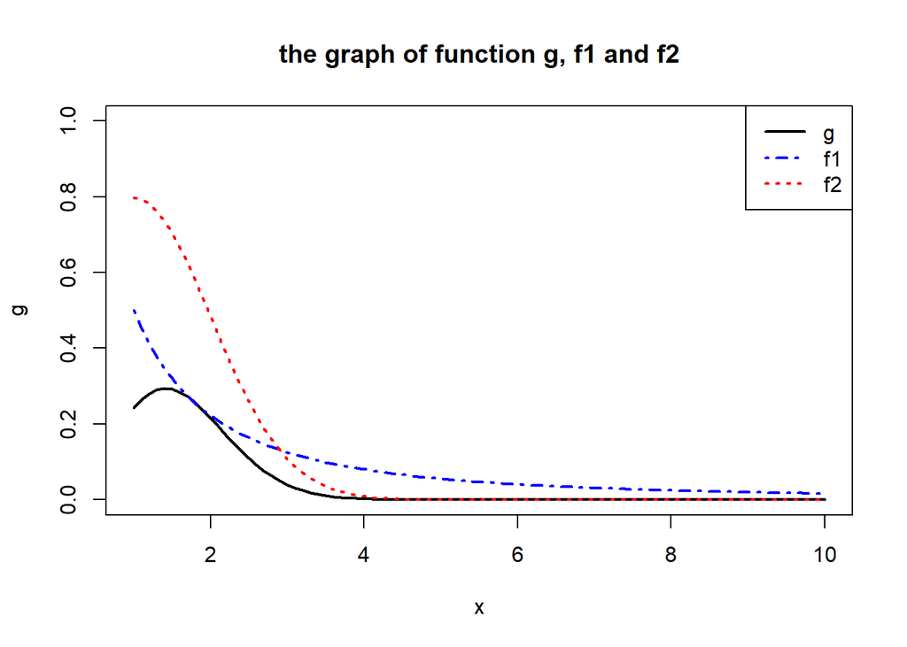

```r
x = seq(1,10,by=0.1)
g = x^2*exp(-x^2/2)/sqrt(2*pi)
plot(x,g,type='l',col='black',ylim=c(0,1),lwd=2,main='the graph of function g, f1 and f2')
f1 = 2/(x+1)^2
lines(x,f1,lty=4,col='blue',lwd=2)
f2 = 2*dnorm(x,mean=1,sd=1)
lines(x,f2,lty=3,col='red',lwd=2)
legend('topright',legend=c('g','f1','f2'),col=c('black','blue','red'),lwd=c(2,2,2),lty=c(1,4,3))
```

To check which one is closer in shape to $g(x)$, I also plot the ratio of $g(x)/f_1(x)$ and $g(x)/f_2(x)$.

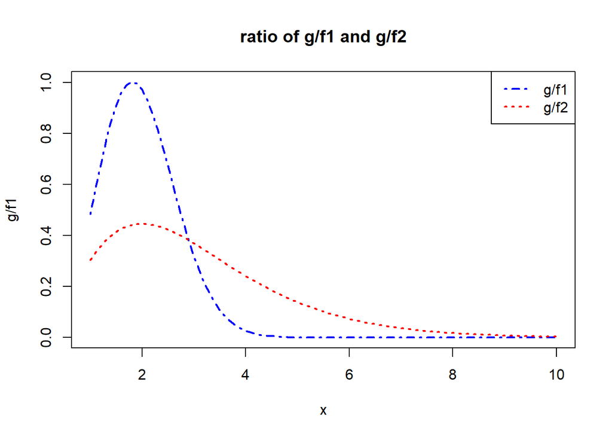

```r
plot(x,g/f1,type='l',col='blue',lwd=2,lty=4,main='ratio of g/f1 and g/f2')
lines(x,g/f2,lty=3,col='red',lwd=2)
legend('topright',legend=c('g/f1','g/f2'),col=c('blue','red'),lwd=c(2,2),lty=c(4,3))
```

**Since $g(x)/f_2(x)$ is more close to a constant, I consider $f_2(x)$ can produce a smaller variance in estimating $g(x)$.** Here is a numerical experiment to validate it:

```r
set.seed(555)
m = 10000
theta.hat <- variance <- numeric(2)
g = function(x){
  x^2*exp(-x^2/2)/sqrt(2*pi)*(x>1)
}
# using f1
u = runif(m)
x = 2/(1-u) - 1 # inverse transform method
fg = g(x)/(2/(x+1)^2)
theta.hat[1] = mean(fg)
variance[1] = var(fg)
# using f2
x = numeric(m)
i = 1
while(i<=m){
  temp  = rnorm(1,mean=1,sd=1)
  if(temp>1) {
    x[i] =temp
    i = i+1}
}

fg = g(x)/(2*dnorm(x,mean=1,sd=1))
theta.hat[2] = mean(fg)
variance[2] = var(fg)
t = rbind(theta.hat,variance)
colnames(t) = c('by f1','by f2')
print(t)
```

```
##               by f1       by f2
## theta.hat 0.3984652 0.400042383
## variance  0.1563752 0.001982161
```

The variance produced by $f_2(x)$ is about **99% smaller** than the variance by $f_1(x)$, which validates my hypothesis.

Moreover, since the estimate produced by $f_2(x)$ **is more precisely, I chose $\hat{\theta}^{IS}_f = 0.400042383$ as my estimate.**

$\blacksquare$

## Proof of Proposition 5.3 on Textbook

At first, I shall define some notations. Let $I_j = \{x:a_{j-1}\le x < a_j\}$ and the probability that x falls in to $I_j$ is $1/k$.

Let
$$\theta_j =
\int_{I_j}g_j(x)\,dx$$
and therefore $\theta = \theta_1 + \cdots + \theta_k$.

In addition, we should shift up $f(x)$ in every $I_j$ as $f_j(x) = kf(x),\quad x\in I_j$. Generating $X$ from $f_j$ and we have $\theta_j = \text{E}_{f_j}\left[ \frac{g_i(X)}{f_j(X)} \right]$ and $\sigma_j^2 = \text{Var}\left(\frac{g_i(X)}{f_j(X)}\right)$. We will compute the importance sampling estimator $\hat{\theta_j}$ with $m=\frac{M}{k}$replicates for every $I_j$ and compute $\hat{\theta}^{SI} = \sum_{j=1}^k\hat{\theta}_j$. And we have $\text{ Var}\left(\hat{\theta}^{SI}\right) = \sum_{j=1}^{k}\frac{\sigma_j^2}{m} = \frac{1}{m}\sum_{j=1}^{k}\sigma_j^2$.

As for the importance sampling, let $Y=\frac{g(X)}{f(x)}$ and we have $\theta = \text{E}_{f}\left[\frac{g(X)}{f(X)}\right]=\text{E}_{f}[Y]$. Moreover, if M replicates are generated for importance sampling estimate, i.e., $\hat{\theta}^I$, then $\text{Var}(\hat{\theta}^I)=\frac{\sigma^2}{M}$, where $\sigma^2=\text{Var}\left(\frac{g(X)}{f(X)} \right) = \text{Var}(Y)$. Now the task is to show that
$$\text{Var}\left(\hat{\theta}^I\right) \ge
\text{ Var}\left(\hat{\theta}^{SI}\right)$$

Consider the two-stage experiment. First generate $J$ from $1$ to $k$ with equal probability $1/k$. After observing $J=j$, find the corresponding interval $I_j$ and generate a random variable $X^*$ from density $f_j(x)$. After that, we calculate

$$\begin{align*}
Y^* = \frac{g_j(X)}{f_j(X)} = \frac{g_j(X)}{kf(X*)}
\end{align*}$$

First I will prove $X$ and $X^*$ has the same distribution. If $x_0$ come from a certain interval $I_{j_0}$, then

$$\begin{align*}
\text{P}(X^{*}=x_0) &= \sum_{j}\text{P}(X^{*}=x_0|x_0\in
I_{j})\text{P}(x_0\in I_{j})\\
&= \text{P}(X^{*}=x_0|x_0\in I_{j_0})\text{P}(x_0\in I_{j_0})\\
&=k\times f(x_0)\times \frac{1}{k} \\
&= f(x_0) \\
& = \text{P}(X=x_0)
\end{align*}$$

As for $Y^*$, quite similarly to the proof of $X^*$, we still let $x_0$ come from a certain interval $I_{j_0}$ and calculate $Y^*_0 = \frac{g_i(x_0)}{f_i(x_0)} = \frac{g_i(x_0)}{kf(x_0)}$.

And we have

$$\begin{align*}
\text{P}(Y^{*}=Y^*_0)
&=\text{P}\left(Y^*=\frac{g_i(x_0)}{kf(x_0)}\right) \\
&=\sum_{j}\text{P} \left( Y^* = \frac{g_i(x_0)}{k f(x_0)} | x_0 \in
I_{j} \right)\text{P}(x_0\in I_{j})\\
&= \text{P}\left(Y^{*}=\frac{g_i(x_0)}{k f(x_0)}|x_0\in
I_{j_0}\right)\text{P}(x_0\in I_{j_0})\\
&= k\times f(x_0) \times \frac{1}{k} \\
&= f(x_0)
\end{align*}$$

On the other hand, as for $\frac{Y}{k} = \frac{g(x)}{kf(x)}$, we have:

$$\begin{align*}
\text{P}\left(\frac{Y}{k} = \frac{Y_0}{k}\right)
&= \text{P}\left(\frac{Y}{k} = \frac{g(x_0)}{kf(x_0)}\right) \\
&= \text{P}(x = x_0)\\
&= f(x_0)
\end{align*}$$

**Then we have proved that $X^*$ and $X$ have the same distribution , so do $Y^*$ and $Y/k$.**

Using the conditional variance formula, we can derive the variance of $Y^*$:
$$\text{Var}(Y^*) =
\text{E}[\text{Var}(Y^*|J)]+\text{Var}(\text{E}[Y^*|J])$$
where
$$\text{E}[\text{Var}(Y^*|J)] = \sum_{j=1}^k
\sigma_j^2\text{P}(J=j) = \frac{1}{k}\sum_{j=1}^k \sigma_j^2$$
and
$$\text{Var}(\text{E}[Y^*|J]) =
\text{Var}(\theta_J)$$

Therefore we have
$$\text{Var}(Y^*)
=\frac{1}{k}\sum_{j=1}^k \sigma_j^2 +\text{Var}(\theta_J)$$

And we have
$$\begin{align*}
\sigma^2 &= \text{Var}(Y) \\
&= \text{Var}(kY^*) \\
&= k^2\text{Var}(Y^*)\\
&= k^2\left[\frac{1}{k}\sum_{j=1}^k \sigma_j^2
+\text{Var}(\theta_J) \right] \\
&= k\sum_{j=1}^k \sigma_j^2 +k^2\text{Var}(\theta_J)\\
\end{align*}$$

Then finally we have

$$\begin{align*}
\sigma^2 - k\sum_{j=1}^k \sigma_j^2 = k^2\text{Var}(\theta_J) \ge 0
\end{align*}$$

which means
$$\begin{align*}
&\quad \sigma^2 - k\sum_{j=1}^k \sigma_j^2 \ge 0\\
&\Rightarrow \frac{1}{M}\sigma^2 - \frac{k}{M}\sum_{j=1}^k
\sigma_j^2 \ge 0 \\
&\Rightarrow \frac{1}{M}\sigma^2 - \frac{1}{m}\sum_{j=1}^k
\sigma_j^2 \ge 0 \\
&\Rightarrow \text{Var}\left(\hat{\theta}^I\right) - \text{
Var}\left(\hat{\theta}^{SI}\right) \ge 0
\end{align*}$$

$\blacksquare$